# Interactive Data Visualizatin in HR

**Q:** Please download the HR analytics dataset from kaggle (link below). Study the dataset, explore it, and prepare a few figures/visualizations that either help to better understand the dataset at a glance or it shows some interesting aspects of it. Please prepare 3 to max 5 figures/visualizations in your notebook/markdown. https://www.kaggle.com/ludobenistant/hr-analytics

### Prepare data and the library

```python
## https://stackoverflow.com/questions/13411544/delete-column-from-pandas-dataframe
import numpy as np
import pandas as pd
import matplotlib.pyplot as plt
import plotly.plotly as py
from plotly.graph_objs import *
from plotly import tools
import plotly.graph_objs as go
import subprocess
import math

df_hr = pd.read_csv('./data/HR_comma_sep.csv')

## switch the left column to the end
##df_hr.drop(['sales', 'salary'], axis = 1, inplace = True)
df_hr_switch = df_hr.drop(['sales', 'salary'], axis = 1, inplace = False)
df_hr_reordered = df_hr_switch.reindex_axis(list( \
                  [a for a in df_hr_switch.columns if a != 'left']) + ['left'], axis=1)
```

### The data report

```python
## Some statistical information about the dataset
print (df_hr.describe())
```

```
       satisfaction_level  last_evaluation  number_project  \
count        14999.000000     14999.000000    14999.000000
mean             0.612834         0.716102        3.803054
std              0.248631         0.171169        1.232592
min              0.090000         0.360000        2.000000
25%              0.440000         0.560000        3.000000
50%              0.640000         0.720000        4.000000
75%              0.820000         0.870000        5.000000
max              1.000000         1.000000        7.000000

       average_montly_hours  time_spend_company  Work_accident          left  \
count          14999.000000        14999.000000   14999.000000  14999.000000
mean             201.050337            3.498233       0.144610      0.238083
std               49.943099            1.460136       0.351719      0.425924
min               96.000000            2.000000       0.000000      0.000000
25%              156.000000            3.000000       0.000000      0.000000
50%              200.000000            3.000000       0.000000      0.000000
75%              245.000000            4.000000       0.000000      0.000000
max              310.000000           10.000000       1.000000      1.000000

       promotion_last_5years
count           14999.000000
mean                0.021268
std                 0.144281
min                 0.000000
25%                 0.000000
50%                 0.000000
75%                 0.000000
max                 1.000000
```

### Prepare data in two group: all employees and high-evaluated employees

```python
dic_sales_index_type = {}
dic_sales_type_sat_level = {}
dic_sales_type_sat_level_criteria = {}
dic_sales_type_sat_level_salary = {}
dic_sales_type_sat_level_high_high = {}

dic_sales_type_left = {}
dic_sales_type_high_salary_left = {}
dic_sales_type_high_evaluation_left = {}

count_index = 1

for job_type in set(df_hr['sales']):

    df_sales = df_hr.loc[(df_hr['sales'] == job_type)]
    dic_sales_index_type[count_index] = job_type

    each_list = list(df_sales['satisfaction_level'])

    each_list_criteria = list(df_sales['satisfaction_level'].loc[(df_sales['last_evaluation'] >= 0.8) ])
    each_list_salary = list(df_sales['satisfaction_level'].loc[(df_sales['salary'] == 'high') ])

    dic_sales_type_sat_level[job_type] = each_list
    dic_sales_type_sat_level_criteria[job_type] = each_list_criteria

    dic_sales_type_sat_level_salary[job_type] = each_list_salary

    ## all employees and (left, stay)
    each_list_left = list(df_sales['left'] )
    dic_sales_type_left[job_type] = \
    (each_list_left.count(1), each_list_left.count(0))

    ## high salary and (left, stay)
    each_list_high_salary_left = list(df_sales['left'].loc[(df_sales['salary'] == 'high')])
    dic_sales_type_high_salary_left[job_type] = \
    (each_list_high_salary_left.count(1), each_list_high_salary_left.count(0))

    ## high evaluation and (left, stay)
    each_list_high_evaluation_left = list(df_sales['left'].loc[(df_sales['last_evaluation'] >= 0.8)])
    dic_sales_type_high_evaluation_left[job_type] = \
    (each_list_high_evaluation_left.count(1), each_list_high_evaluation_left.count(0))

    count_index += 1

print ("Group by different department")
print (dic_sales_index_type)

print ("\nTotal Employees " + "-" * 50)
print ([len(i) for i in dic_sales_type_sat_level.values()  ])
print ("Count: {}".format(sum([len(i) for i in dic_sales_type_sat_level.values()  ])))

print ("\nHigh Evaluated Employees " + "-" * 50)
print ([len(i) for i in dic_sales_type_sat_level_criteria.values()  ])
print ("Count: {}".format(sum([len(i) for i in dic_sales_type_sat_level_criteria.values()  ])))

print ("\nHigh Salary Employees " + "-" * 50)
print ([len(i) for i in dic_sales_type_sat_level_salary.values()  ])
print ("Count: {}".format(sum([len(i) for i in dic_sales_type_sat_level_salary.values()  ])))
```

```
Group by different department
{1: 'product_mng', 2: 'IT', 3: 'accounting', 4: 'hr', 5: 'RandD', 6: 'support', 7: 'marketing', 8: 'management', 9: 'technical', 10: 'sales'}

Total Employees --------------------------------------------------
[902, 1227, 767, 739, 787, 2229, 858, 630, 2720, 4140]
Count: 14999

High Evaluated Employees --------------------------------------------------
[349, 478, 295, 276, 280, 915, 334, 225, 1070, 1518]
Count: 5740

High Salary Employees --------------------------------------------------
[68, 83, 74, 45, 51, 141, 80, 225, 201, 269]
Count: 1237
```

### Random number generator

```python
## Randomly pick desired number of the sample
import math

dic_index_random_list = {}

def rand_theta(n_of_trace, sample_size):
    each_segment = math.floor(360/n_of_trace)
    start_t = 0
    end_t = 0
    for i in range(1, n_of_trace+1):
        start_t = (i-1)*each_segment
        end_t = i*each_segment
        dic_index_random_list[i] = np.random.uniform(start_t, end_t,size=sample_size)
    #return dic_index_random_list
    #return 0

rand_theta(10, 250)
```

### Dataframe of worker's satisfaction level in different job categories

```python
import plotly.plotly as py
import plotly.graph_objs as go
import numpy as np
import colorsys

n_of_traces = 10

## cover entire spectrum
HSV_tuples = [((x*1.0/n_of_traces), 0.8, 0.8) for x in range(n_of_traces)]
RGB_tuples = list((map(lambda x: colorsys.hsv_to_rgb(*x), HSV_tuples)))

plt.clf()

trace_list = []
for index_of_trace in range(1,n_of_traces+1):
    trace_item = go.Scatter()
    trace_item.name = dic_sales_index_type[index_of_trace]
    trace_item.mode='markers'
    rgb_string = 'rgb'+str(RGB_tuples[index_of_trace-1])
    trace_item.marker=dict(
                    color=rgb_string,
                    size=110,
                    line=dict(
                    color='white'
                    ),
                    opacity=0.8
                    )
    trace_item.update(r = dic_sales_type_sat_level[dic_sales_index_type[index_of_trace]])
    trace_item.update(t = dic_index_random_list[index_of_trace])

    trace_list.append(trace_item)

layout = go.Layout(
    title='All Employees',
    font=dict(
        size=15
    ),
    #showlegend= False,
    plot_bgcolor='rgb(223, 223, 223)',
    angularaxis=dict(
        tickcolor='rgb(253,253,253)',
        #range=[0,20]
        showticklabels = None
    ),
)

fig1 = go.Figure(data=trace_list, layout=layout)
py.iplot(fig1, filename='plot_all_employees')
```

[interactive chart not shown]

### Dataframe of worker's satisfaction level in different job category

```python
trace_list_criteria = []

for index_of_trace in range(1,n_of_traces+1):
    trace_item = go.Scatter()
    trace_item.name = dic_sales_index_type[index_of_trace]
    trace_item.mode='markers'
    rgb_string = 'rgb'+str(RGB_tuples[index_of_trace-1])
    trace_item.marker=dict(
                    color=rgb_string,
                    size=110,
                    line=dict(
                    color='white'
                    ),
                    opacity=0.8
                    )
    trace_item.update(r = dic_sales_type_sat_level_criteria[dic_sales_index_type[index_of_trace]]          )
    trace_item.update(t = dic_index_random_list[index_of_trace])

    trace_list_criteria.append(trace_item)


layout_second = go.Layout(
    title='High Evaluated Employees',
    font=dict(
        size=15
    ),
    #showlegend= False,
    plot_bgcolor='rgb(223, 223, 223)',
    angularaxis=dict(
        tickcolor='rgb(253,253,253)',
        #range=[0,20]
        showticklabels = None
    ),
)

fig2 = go.Figure(data=trace_list_criteria, layout=layout_second)
py.iplot(fig2, filename='plot_high_e_employees')
```

[interactive chart not shown]

For high-evaluated employees, it is more clear that people in technical, support, and sales department are more satisfied with the position. Unlike management and accounting personnel, their satisfaction levels remain uniformly distributed throughout the graph. There is an interesting observation that high-evaluated personnel tend to give not-so-moderated report on their satisfaction level (not too many data points in the range 0.3-0.5). I feel this analysis could be very useful to understand how people behave, based their personality. Even though such information is quantitative, we couldn't fully rely on its value without knowing the big picture.

## Job Composition

```python
import plotly.plotly as py
import plotly.graph_objs as go
import matplotlib.pyplot as plt

plt.clf()
fig = {
  "data": [
    {
      "values": [len(i) for i in dic_sales_type_sat_level.values()  ],
      "labels": [job_type for job_type in dic_sales_index_type.values() ],
      "domain": {"x": [.25, .75], 'y': [0.52, 1]},
      "name": "Total Employees",
      "hoverinfo":"label+percent+name",
      "pull": .0,
      "hole": .2,
      "type": "pie"
    },

    ## High evaluated employees
    {
      "values": [len(i) for i in dic_sales_type_sat_level_criteria.values()  ],
      "labels": [job_type for job_type in dic_sales_index_type.values() ],
      "domain": {"x": [0, .50], 'y': [0., 0.50]},
      "name": "High Evaluated Employees",
      "hoverinfo":"label+percent+name",
      "pull": .0,
      "hole": .2,
      "type": "pie",
    },

    ## High paid employees

    {
      "values": [len(i) for i in dic_sales_type_sat_level_salary.values()  ],
      "labels": [job_type for job_type in dic_sales_index_type.values() ],
      "domain": {"x": [0.50, 1], 'y': [0., 0.50]},
      "name": "High Paid Employees",
      "hoverinfo":"label+percent+name",
      "pull": .0,
      "hole": .2,
      "type": "pie"
    },

  ],
  "layout": {
        "title":"Job Composition",
        "titlefont": {
        "size": 30
         },
        "annotations": [
            {
                "font": {
                    "size": 20
                },
                "showarrow": False,
                "text": "Total",
                "x": 0.36,
                "y": 1.0
            },
            {
                "font": {
                    "size": 20
                },
                "showarrow": False,
                "text": "High Evaluated",
                "x": 0.12,
                "y": 0.55
            },
            {
                "font": {
                    "size": 20
                },
                "showarrow": False,
                "text": "High Paid",
                "x": 0.86,
                "y": 0.55
            }
        ]
    }
}
py.iplot(fig, filename='multi_donuts')
```

[interactive chart not shown]

The total employees, high evaluated employees, and high paid employees in different job categories are reported. Sales, technical, and support personnel are the majority (60% in total), and each remaining department consists no more than 10% of the total employees. 4% of them are in the management department. If we group them based on their evaluation, the percentage of the composition remains the same as its total composition. However, 18.2% of the employees in management department have high salary, but only 3.92% of employees in management department have high evaluation.

## Left or Stay

```python
print (dic_sales_index_type)

print ("\nEmployees who left " + "-" * 50)
employees_left_stay_tuple_list = [i for i in dic_sales_type_left.values()  ]
#print (employees_left_stay_tuple_list)   # tuple (left, stay)
print ([int(i[0]) for i in employees_left_stay_tuple_list])
print ("Count: {}".format(sum([int(i[0]) for i in employees_left_stay_tuple_list])))

print ("\nHigh evaluation employees who left " + "-" * 50)
high_evaluation_left_stay_tuple_list = [i for i in dic_sales_type_high_evaluation_left.values()  ]
#print (high_evaluation_left_stay_tuple_list)  # tuple (left, stay)
print ([int(i[0]) for i in high_evaluation_left_stay_tuple_list])
print ("Count: {}".format(sum([int(i[0]) for i in  high_evaluation_left_stay_tuple_list])))

print ("\nHigh salary employees who left " + "-" * 50)
high_salary_left_stay_tuple_list = [i for i in dic_sales_type_high_salary_left.values()  ]
#print (high_salary_left_stay_tuple_list)  # tuple (left, stay)
print ([int(i[0]) for i in high_salary_left_stay_tuple_list])
print ("Count: {}".format(sum([int(i[0]) for i in  high_salary_left_stay_tuple_list])))
```

```
{1: 'product_mng', 2: 'IT', 3: 'accounting', 4: 'hr', 5: 'RandD', 6: 'support', 7: 'marketing', 8: 'management', 9: 'technical', 10: 'sales'}

Employees who left --------------------------------------------------
[198, 273, 204, 215, 121, 555, 203, 91, 697, 1014]
Count: 3571

High evaluation employees who left --------------------------------------------------
[102, 145, 93, 82, 62, 285, 88, 43, 364, 478]
Count: 1742

High salary employees who left --------------------------------------------------
[6, 4, 5, 6, 4, 8, 9, 1, 25, 14]
Count: 82
```

```python
import plotly.plotly as py
import plotly.graph_objs as go
import matplotlib.pyplot as plt

plt.clf()
fig = {
  "data": [
    ## Employees who left
    {
      "values": [int(i[0]) for i in employees_left_stay_tuple_list],
      "labels": [job_type for job_type in dic_sales_index_type.values() ],
      "domain": {"x": [.25, .75], 'y': [0.5, 1]},
      "name": "Employees Left",
      "hoverinfo":"label+percent+name",
      "pull": .0,
      "hole": .5,
      "type": "pie"
    },

    ## High evaluated employees who left
    {
      "values": [int(i[0]) for i in high_evaluation_left_stay_tuple_list],
      "labels": [job_type for job_type in dic_sales_index_type.values() ],
      "domain": {"x": [0, .5], 'y': [0, 0.5]},
      "name": "High Evaluated Left",
      "hoverinfo":"label+percent+name",
      "pull": .0,
      "hole": .5,
      "type": "pie",
    },

    ## High paid employees who left
    {
      "values": [int(i[0]) for i in high_salary_left_stay_tuple_list],
      "labels": [job_type for job_type in dic_sales_index_type.values() ],
      "domain": {"x": [.5, 1], 'y': [0, 0.5]},
      "name": "High Paid Left",
      "hoverinfo":"label+percent+name",
      "pull": .0,
      "hole": .5,
      "type": "pie",
    },


  ],
  "layout": {
        "title":"Employees Turnover",
        "titlefont": {
        "size": 30
         },
        "annotations": [
            {
                "font": {
                    "size": 20
                },
                "showarrow": False,
                "text": "Total",
                "x": 0.36,
                "y": 1.0
            },
            {
                "font": {
                    "size": 20
                },
                "showarrow": False,
                "text": "High Evaluated",
                "x": 0.12,
                "y": 0.55
            },
            {
                "font": {
                    "size": 20
                },
                "showarrow": False,
                "text": "High Paid",
                "x": 0.86,
                "y": 0.55
            }
        ]
    }
}
py.iplot(fig, filename='multi_left_or_stay')
```

[interactive chart not shown]

```python
##import plotly.plotly as py
##import plotly.graph_objs as go

sales_left_total  = df_hr[['sales','left']].loc[df_hr['left']==1].groupby('sales')\
                    .count().rename_axis(None).rename(columns={'left': 'left_total'})


sales_left_salary_low  = df_hr[['sales','left']].loc[(df_hr['salary']=='low') & df_hr['left']==1]\
                        .groupby('sales').count().rename_axis(None).rename(columns={'left': 'left_low'})

sales_left_salary_med  = df_hr[['sales','left']].loc[(df_hr['salary']=='medium')& df_hr['left']==1]\
                    .groupby('sales').count().rename_axis(None).rename(columns={'left': 'left_med'})

sales_left_salary_high = df_hr[['sales','left']].loc[(df_hr['salary']=='high')& df_hr['left']==1]\
                    .groupby('sales').count().rename_axis(None).rename(columns={'left': 'left_high'})


## Concatenating the dataframes and sorting in descending order
sales_left_summary = pd.concat([sales_left_total, sales_left_salary_low, sales_left_salary_med, sales_left_salary_high ]\
                               , axis=1).sort_values(by='left_total', ascending=0)

## pd.options.display.float_format = '{:.2f}%'.format
sales_left_summary['low_ratio'] = 100 * sales_left_summary['left_low']/sales_left_summary['left_total']
sales_left_summary['high_ratio'] = 100 * sales_left_summary['left_high']/sales_left_summary['left_total']

## Employees who left with low salary in percentage
low_raio_str_list = [str(math.floor(element))+'%' for element in sales_left_summary['low_ratio'].values ]

print (sales_left_summary)

descending_order = list(sales_left_summary.index.values)
#print (descending_order)
#print (sales_left_summary['left_low'].tolist())

trace1 = go.Bar(
    x=descending_order,
    y=sales_left_summary['left_low'].tolist(),
    name='Salary Low',
    hoverinfo='name+y'
)

trace2 = go.Bar(
    x=descending_order,
    y=sales_left_summary['left_med'].tolist(),
    name='Salary Medium',
    hoverinfo='name+y'
)

trace3 = go.Bar(
    x=descending_order,
    y=sales_left_summary['left_high'].tolist(),
    name='Salary High',
    hoverinfo='name+y'
)

trace4 = go.Scatter(
    x=descending_order,
    y=[50 for _ in descending_order ],
    #mode='markers+text',
    mode='text',
    showlegend= False,
    #showlegend= True,
    name='Left at Low Salary',
    text=low_raio_str_list,
    hoverinfo='none',
    textposition='bottom',
    textfont=dict(
        family='sans serif',
        size=18,
        color='#ffffff'
    )
)


data = [trace1, trace2, trace3, trace4]

layout = go.Layout(
    barmode='stack',
    title='Turnover from Department',
    titlefont= {
        "size": 30
    },
    xaxis=dict(
        title='Department',
        titlefont=dict(
            #family='Courier New, monospace',
            size=18,
            color='#7f7f7f'
        )
    ),
    yaxis=dict(
        title='Count',
        titlefont=dict(
            #family='Courier New, monospace',
            size=18,
            color='#7f7f7f'
        )
    ),
)

fig = go.Figure(data=data, layout=layout)
py.iplot(fig, filename='stacked_bar_salary')
```

```
             left_total  left_low  left_med  left_high  low_ratio  high_ratio
sales              1014       697       303         14  68.737673    1.380671
technical           697       378       294         25  54.232425    3.586801
support             555       389       158          8  70.090090    1.441441
IT                  273       172        97          4  63.003663    1.465201
hr                  215        92       117          6  42.790698    2.790698
accounting          204        99       100          5  48.529412    2.450980
marketing           203       126        68          9  62.068966    4.433498
product_mng         198       105        87          6  53.030303    3.030303
RandD               121        55        62          4  45.454545    3.305785
management           91        59        31          1  64.835165    1.098901
```

[interactive chart not shown]

In previous plot (Employees Turnover), the number of former employees is compared between department. A great portion of turnover comes from sales, technical, and support department. Here, we show the head count of employees who left taking their salary into account. As what we could expect, the turnover rate of the employees with high salary is very low, in the range of 1% to 4.5%. On the other hand, the turnover rate of the employees with low salary varies between departments. It can go up to 70% while salary is low, from support department. It can go down to 42%, where hr personnel quit their job while salary is low. With large enough data, the analysis combining with other census data could provide useful information regarding the turnover rate throughout the departments.

## Correlation Matrix

```python
## https://plot.ly/python/subplots/

from sklearn.preprocessing import StandardScaler
from sklearn_pandas import DataFrameMapper

## all employees dataframe
all_emp = df_hr_reordered.drop('last_evaluation', axis = 1)
mapper_all_emp = DataFrameMapper([(all_emp.columns, StandardScaler())])
scaled_features_all_emp = mapper_all_emp.fit_transform(all_emp.copy(), 4)
scaled_features_df = pd.DataFrame(scaled_features_all_emp, index=all_emp.index, columns=all_emp.columns)

## high evaluated employees dataframe
eval_high = df_hr_reordered.loc[df_hr_reordered['last_evaluation']>0.8 ].drop('last_evaluation', axis = 1)
mapper_eval_high = DataFrameMapper([(eval_high.columns, StandardScaler())])
scaled_features_eval_high = mapper_eval_high.fit_transform(eval_high.copy(), 4)
scaled_features_df_eval_high = pd.DataFrame(scaled_features_eval_high, index=eval_high.index, columns=eval_high.columns)

trace1 = {
  "x": list(all_emp),
  "y": list(all_emp),
  "z": scaled_features_df.corr().values.tolist(),
  "colorscale": ['RdYIGn'],
  "showscale": True,
  "name": "trace1",
  "type": "heatmap",
  "zmax": 0.9,
  "zmin": -0.9
}

trace2 = {
  "x": list(eval_high),
  "y": list(eval_high),
  "z": scaled_features_df_eval_high.corr().values.tolist(),
  "colorscale": ['RdYIGn'],
  "showscale": True,
  "name": "trace2",
  "type": "heatmap",
  "zmax": 0.9,
  "zmin": -0.9
}

plt.clf()
fig = tools.make_subplots(rows=1, cols=2, print_grid=False, \
                          horizontal_spacing = 0.02, \
                          subplot_titles=('All Employees', 'High Evaluated Employees'),
                          shared_yaxes=True
                         )

fig.append_trace(trace1, 1, 1)
fig.append_trace(trace2, 1, 2)

fig['layout'].update(height=600, width=800, title='Correlation Matrix', \
                    margin=go.Margin(
        l=150,
        r=100,
        b=100,
        t=100,
        pad=4
    ))
py.iplot(fig, filename='subplot_correlation')
```

[interactive chart not shown]

All the employees are included on the left-hand side, and only high evaluated employees (last_evaluation > 0.8) are considered on the right-hand side of the correlation matrix plot. We observe that time spend in company, average monthly hours, and number of project are correlated to each other. It is logical that more time you spend in the company, the average hours should be higher, and probably more tasks/projects are on your hand. Moreover, the satisfaction level is negatively correlated to whether the employee left or not. If the employee isn't satisfied with the company (low satisfaction level), they have a higher chance to leave their work.

We can see very similar relationship among high evaluated employees that the more work they have to do, more time they have to spend in the company. More interestingly, the high evaluated employees decided to leave not only because of the low satisfaction level, but also due to the heavy work load. It is very reasonable because the managers should tempt to distribute the assignment to the people they trust, whom is very likely to be the "good" employee.

## Decision Tree

**Note:** I was trying to use decision tree algorithms on the dataset in order to find out the most probable reason, or the mixture of the reasons about good employees leave. Multiple scenarios are attempted but the final result is way below the satisfaction. The lesson I have learned from the assignment was valuable, so that I decided to include the result for completeness.

### Data preparation

```python
from sklearn.tree import DecisionTreeClassifier, export_graphviz
df_hr_class = pd.read_csv('./data/HR_comma_sep.csv')
print (df_hr_class.columns)
```

```
Index(['satisfaction_level', 'last_evaluation', 'number_project',
       'average_montly_hours', 'time_spend_company', 'Work_accident', 'left',
       'promotion_last_5years', 'sales', 'salary'],
      dtype='object')
```

```python
df_hr_class.drop(['Work_accident', 'sales', \
                  'salary'], axis = 1, inplace = True)
#print (df_hr_class.columns)
```

### Sampling

```python
who_left = df_hr_class[ df_hr_class['left'] == 1]
who_stay = df_hr_class[ df_hr_class['left'] == 0]

#print (len(who_left))
#print (len(who_stay))

who_left_sample = who_left.sample(n=2000, replace=False, random_state=123)
who_stay_sample = who_stay.sample(n=2000, replace=False, random_state=123)

#print (len(who_left_sample))
#print (len(who_stay_sample))

df_sample = pd.concat([who_left_sample, who_stay_sample  ])

#print (df_sample.columns)
```

### Scaling and standardization

```python
from sklearn.preprocessing import StandardScaler
from sklearn_pandas import DataFrameMapper

## all employees dataframe
mapper_my_class = DataFrameMapper([(df_sample.columns, StandardScaler())])
scaled_features_my_class = mapper_my_class.fit_transform(df_sample.copy())
scaled_features_my_class_df = pd.DataFrame(scaled_features_my_class, index=df_sample.index, columns=df_sample.columns)

#print (np.unique(scaled_features_my_class_df['left']))
```

```python
y = scaled_features_my_class_df['left']

scaled_features_my_class_df.drop(['left', 'number_project', 'satisfaction_level', 'time_spend_company', 'promotion_last_5years'], axis = 1, inplace = True)
features = list(scaled_features_my_class_df.columns)

print("* features:", features, sep="\n")

X = scaled_features_my_class_df[features]

dt = DecisionTreeClassifier(min_samples_split=200, random_state=99)
dt.fit(X, y)
```

```
* features:
['last_evaluation', 'average_montly_hours']
```

```
DecisionTreeClassifier(class_weight=None, criterion='gini', max_depth=None,
            max_features=None, max_leaf_nodes=None,
            min_impurity_split=1e-07, min_samples_leaf=1,
            min_samples_split=200, min_weight_fraction_leaf=0.0,
            presort=False, random_state=99, splitter='best')
```

### Visualization using graphviz package

```python
from IPython.core.display import Image, display

def visualize_tree(tree, feature_names):
    """Create tree png using graphviz.
    Args
    ----
    tree -- scikit-learn DecsisionTree.
    feature_names -- list of feature names.
    """
    with open("dt_hr.dot", 'w') as f:
        export_graphviz(tree, out_file=f,
                        feature_names=feature_names)

    command = ["dot", "-Tpng", "dt_hr.dot", "-o", "dt_hr.png"]
    try:
        subprocess.check_call(command)
    except:
        exit("Could not run dot, ie graphviz, to "
             "produce visualization")

    display(Image(filename='dt_hr.png'))
```

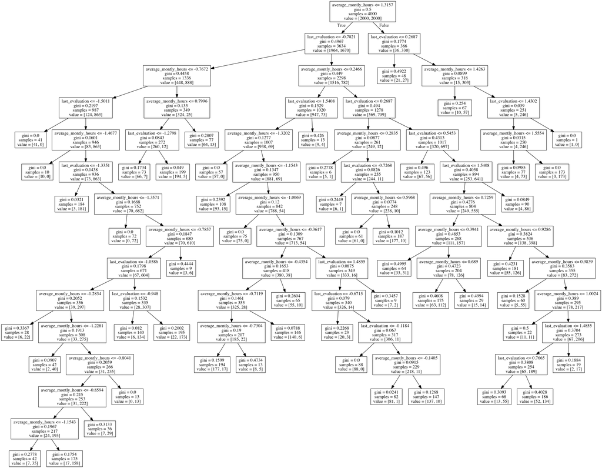

```python
visualize_tree(dt, features)
```

**Final thought:** The strength of decision trees analysis is to provide a quantified method for all the possible consequences. From our correlation matrix analysis, we should notice that there is not such a clear path of identifying one of the features from "a few" of others. The know-how is the essential idea of machine learning, use the "right" model for the specific task.

## Reference

- https://www.google.com/search?q=rgb+color+picker&oq=rgb&aqs=chrome.1.69i57j0l5.2822j1j1&sourceid=chrome&ie=UTF-8
- https://stackoverflow.com/questions/35723472/how-to-use-sklearn-fit-transform-with-pandas-and-return-dataframe-instead-of-num
- https://stackoverflow.com/questions/19913659/pandas-conditional-creation-of-a-series-dataframe-column
- https://pandas.pydata.org/pandas-docs/stable/merging.html